# nCov2019: A R package for studying COVID-19 coronavirus outbreak

## Visualization

We provide a visualization function as a redesign “plot”.

```
 plot(
   x,
   region = "Global",
   continuous_scale = FALSE,
   palette = "Reds",
   date = NULL,
   from = NULL,
   to = NULL,
   title = "COVID-19",
   type = "cases",
   ...
 )
```

Here, type could be one of “cases”,“deaths”,“recovered”,“active”,“todayCases”,“todayDeaths”,“todayRecovered”,“population” and “tests”. By default, color palette is “Reds”, more color palettes can be found here: [palette](https://www.r-graph-gallery.com/38-rcolorbrewers-palettes.html)

To get the overview for the latest status, the mini code required is as below:

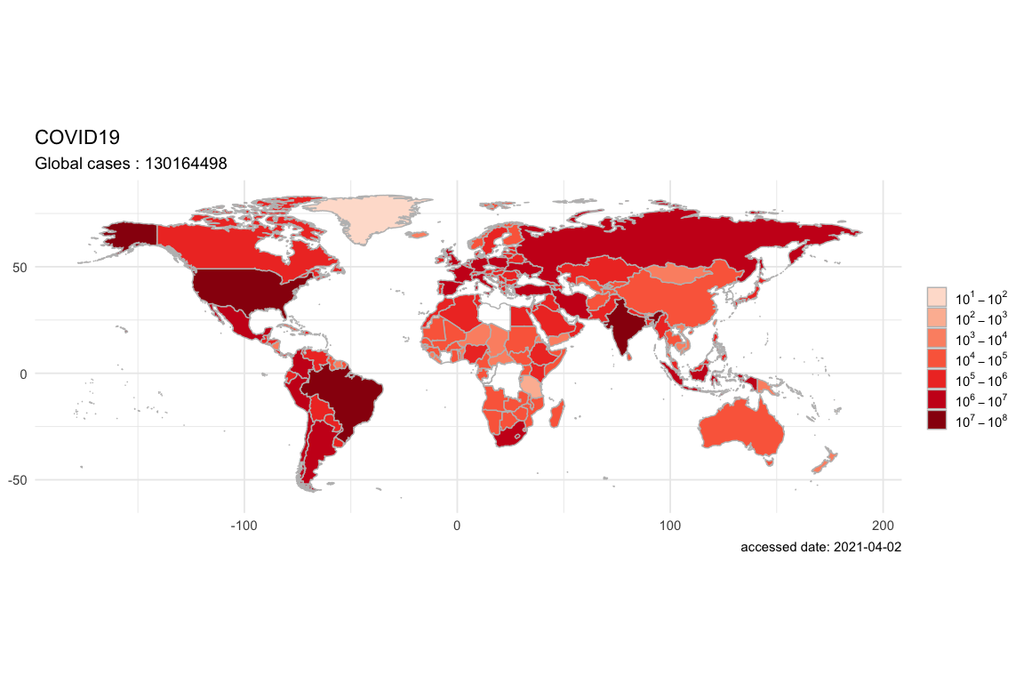

```r
X <- res$latest
plot(X)
```

Or To get the overview for the detection testing status,

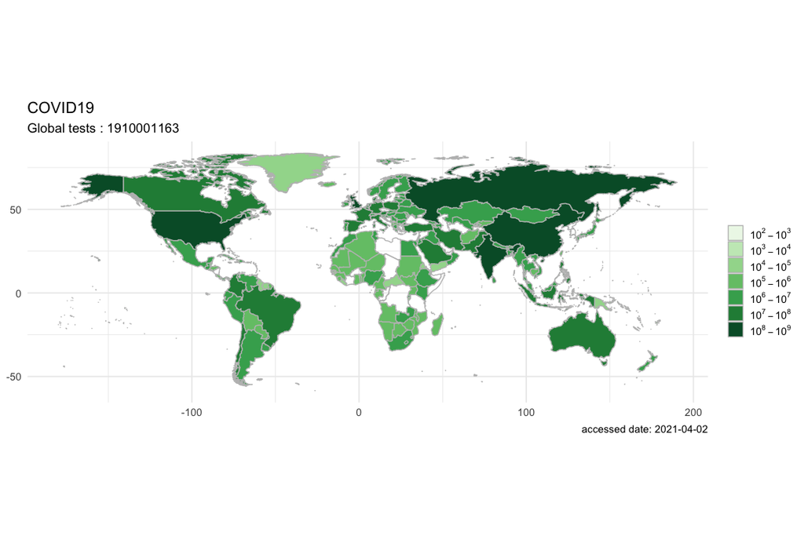

```r
plot(X, type="tests",palette="Green")
```

It could be also intuitively compare the number of new confirmed cases per day among different countries.

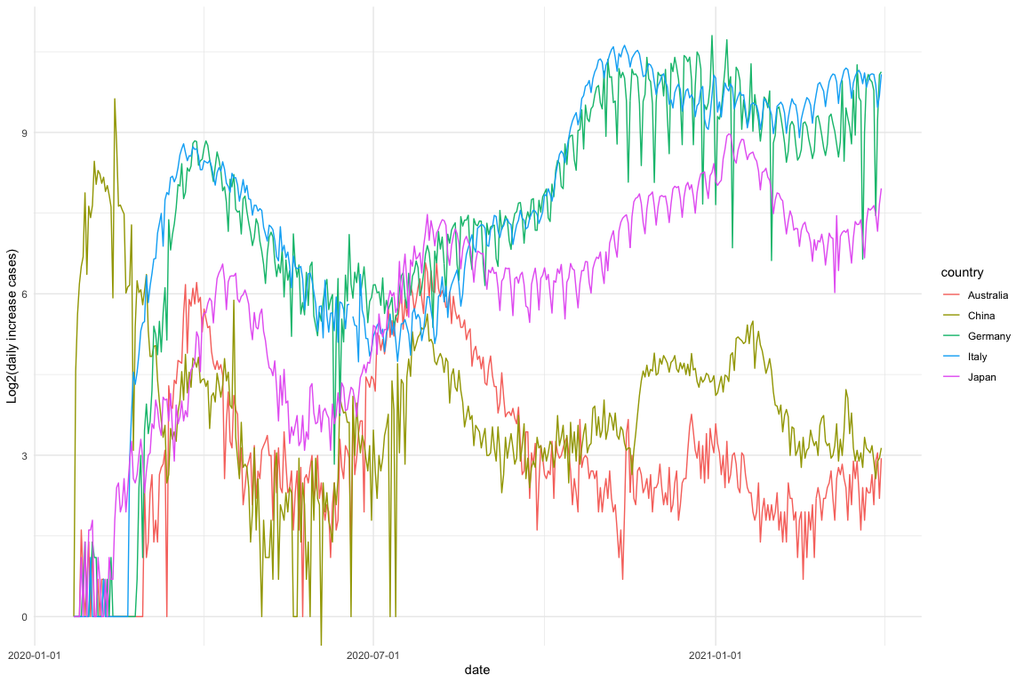

```r
library(ggplot2)
library(dplyr)
X <- res$historical
tmp <- X["global"] %>%
  group_by(country) %>%
  arrange(country,date) %>%
  mutate(diff = cases - lag(cases, default =  first(cases))) %>%
  filter(country %in% c("Australia", "Japan", "Italy", "Germany",  "China"))

ggplot(tmp,aes(date, log(diff+1), color=country)) + geom_line() +
  labs(y="Log2(daily increase cases)") +
  theme(axis.text = element_text(angle = 15, hjust = 1)) +
  scale_x_date(date_labels = "%Y-%m-%d") +
  theme_minimal()
```

user could also plot the outbreak map on the past time with historical data by specify a date in function plot().

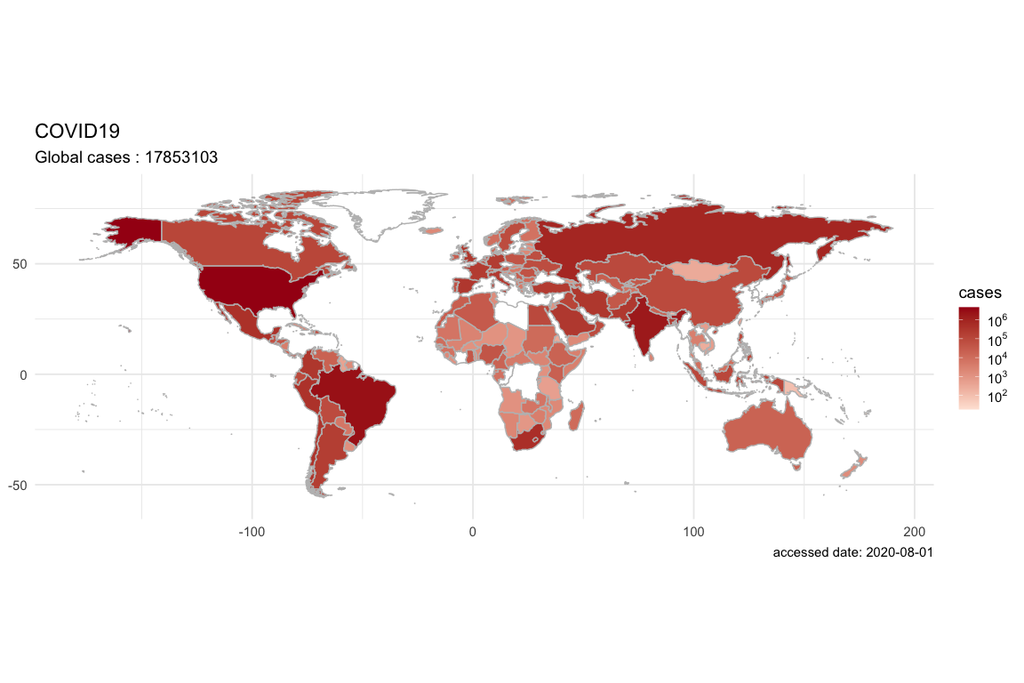

```r
Y <- res$historical
plot(Y, region="Global" ,date = "2020-08-01", type="cases")
```

## Animations plot

Animated world-wide epidemic maps could be generated in the similar way. This is the example to draw a spread animation from 2020-03-01 to 2020-08-01, with little code.

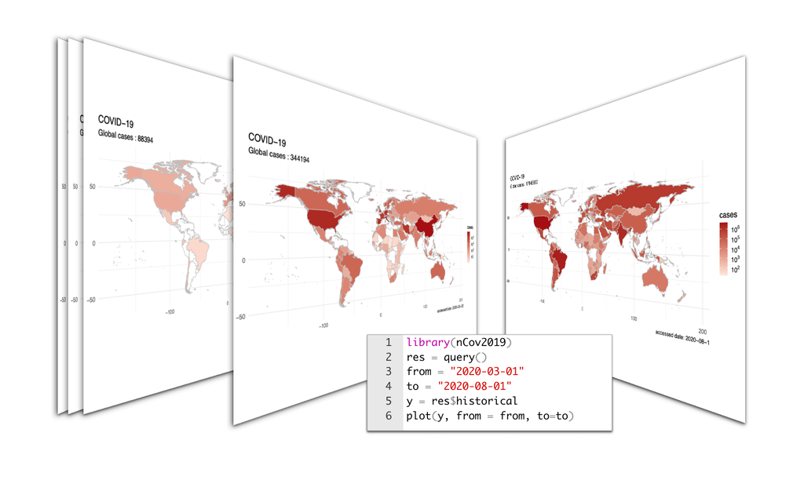

```r
library(nCov2019)
res = query()
from = "2020-03-01"
to = "2020-08-01"
y = res$historical
plot(y, from = from, to=to)
```

## Other plots

If you wanted to visualize the cumulative summary data, an example plot could be the following:

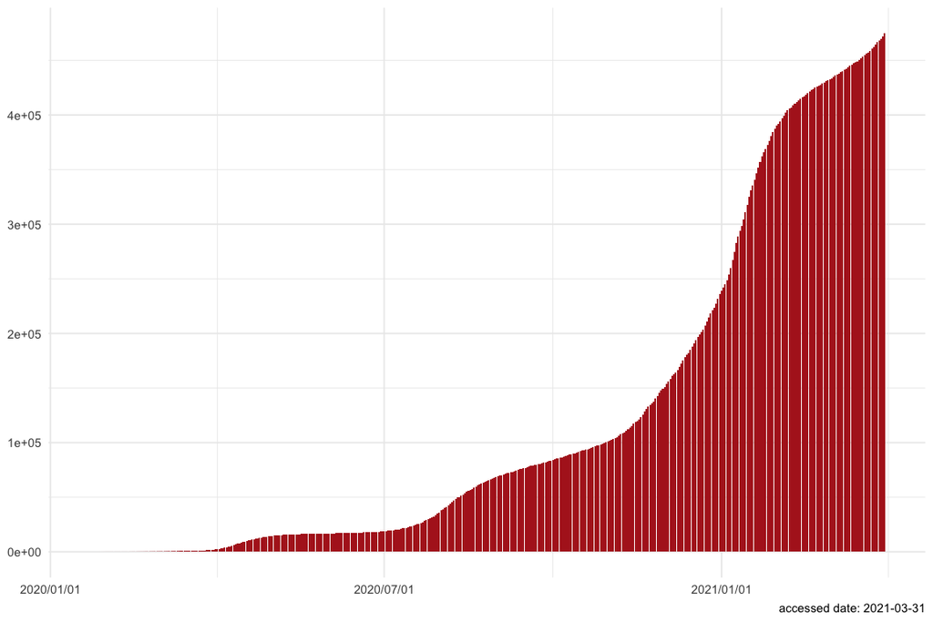

```r
library(ggplot2)
x <- res$historical
d = x['Japan' ] # you can replace Anhui with any province
d = d[order(d$cases), ]

ggplot(d,
       aes(date, cases)) +
  geom_col(fill = 'firebrick') +
  theme_minimal(base_size = 14) +
  xlab(NULL) + ylab(NULL) +
  scale_x_date(date_labels = "%Y/%m/%d") +
  labs(caption = paste("accessed date:", max(d$date)))
```

Plot the trend for for the Top 10 increase cases countries on last day

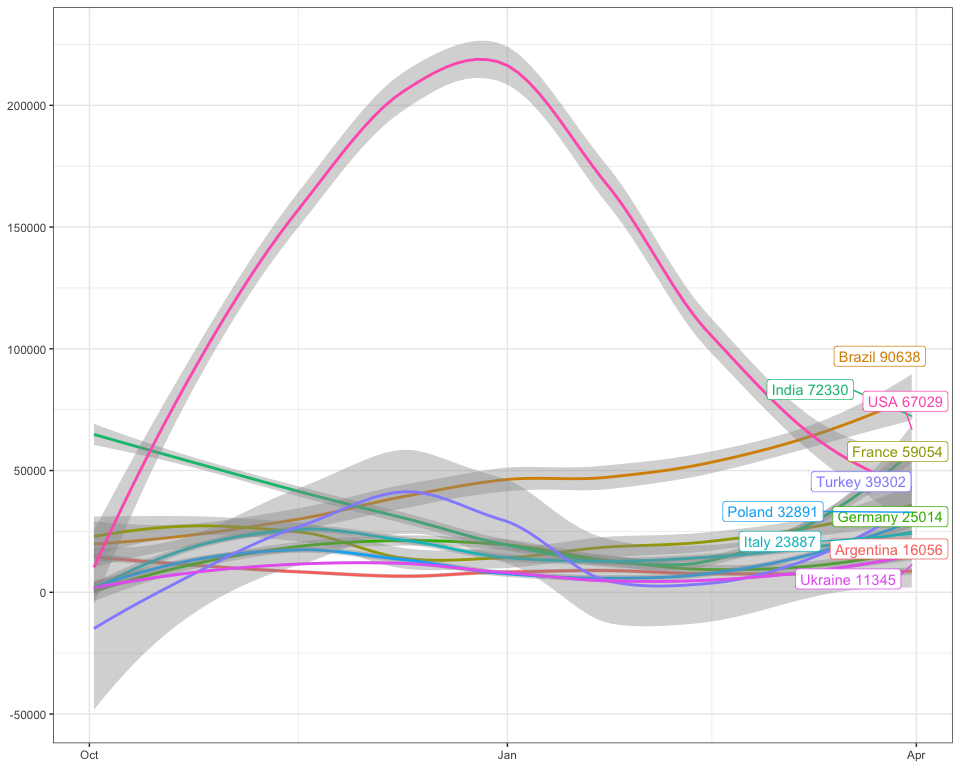

```r
library("dplyr")
library("ggrepel")

x <- res$latest
y <- res$historical

country_list =  x["global"]$country[1:10]

y[country_list]  %>%
subset( date > as.Date("2020-10-01") ) %>%
group_by(country) %>%
arrange(country,date) %>%
mutate(increase = cases - lag(cases, default =  first(cases))) -> df

ggplot(df, aes(x=date, y=increase, color=country  ))+
  geom_smooth() +
  geom_label_repel(aes(label = paste(country,increase)),
    data = df[df$date == max(df$date), ], hjust = 1) +
  labs(x=NULL,y=NULL)+
  theme_bw() + theme(legend.position = 'none')
```

Plot the curve of cases, recovered and deaths for specify country

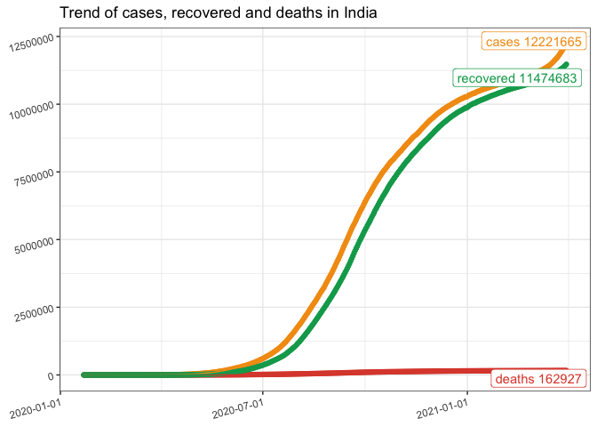

```r
library('tidyr')
library('ggrepel')
library('ggplot2')
y <- res$historical
country = "India"

y[country] -> d
d <- gather(d, curve, count, -date, -country)

ggplot(d, aes(date, count, color = curve)) + geom_point() + geom_line() +
  labs(x=NULL,y=NULL,title=paste("Trend of cases, recovered and deaths in", country)) +
    scale_color_manual(values=c("#f39c12", "#dd4b39", "#00a65a")) +
    theme_bw() +
  geom_label_repel(aes(label = paste(curve,count)),
                   data = d[d$date == max(d$date), ], hjust = 1) +
  theme(legend.position = "none",
        axis.text = element_text(angle = 15, hjust = 1)) +
  scale_x_date(date_labels = "%Y-%m-%d")
```

## Heatmap for cases per country

Here is the example code for draw a heatmap for the historical data range in nCov2019.

```r
library('tidyr')
library('ggrepel')
library('ggplot2')
y <- res$historical
d <- y["global"]

d <- d[d$cases > 0,]
length(unique(d$country))
```

```
## [1] 192
```

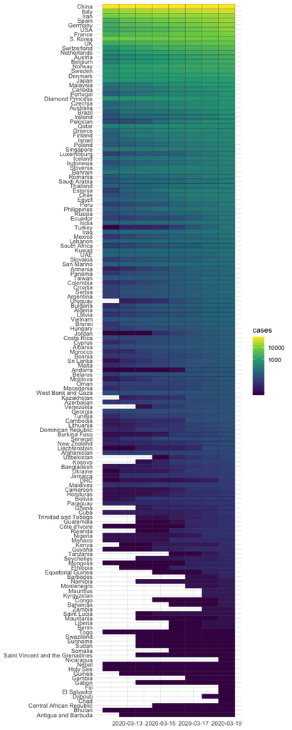

```r
d <- subset(d,date <= as.Date("2020-3-19"))
max_time <- max(d$date)
min_time <- max_time - 7
d <-  d[d$date >= min_time,]
dd <- d[d$date == max(d$date,na.rm = TRUE),]

d$country <- factor(d$country,
  levels=unique(dd$country[order(dd$cases)]))
breaks = c(0,1000, 10000, 100000, 10000000)

ggplot(d, aes(date, country)) +
  geom_tile(aes(fill = cases), color = 'black') +
  scale_fill_viridis_c(trans = 'log', breaks = breaks,
  labels = breaks) +
  xlab(NULL) + ylab(NULL) +
  scale_x_date(date_labels = "%Y-%m-%d") + theme_minimal()
```

Plot the global trend in a novel way.

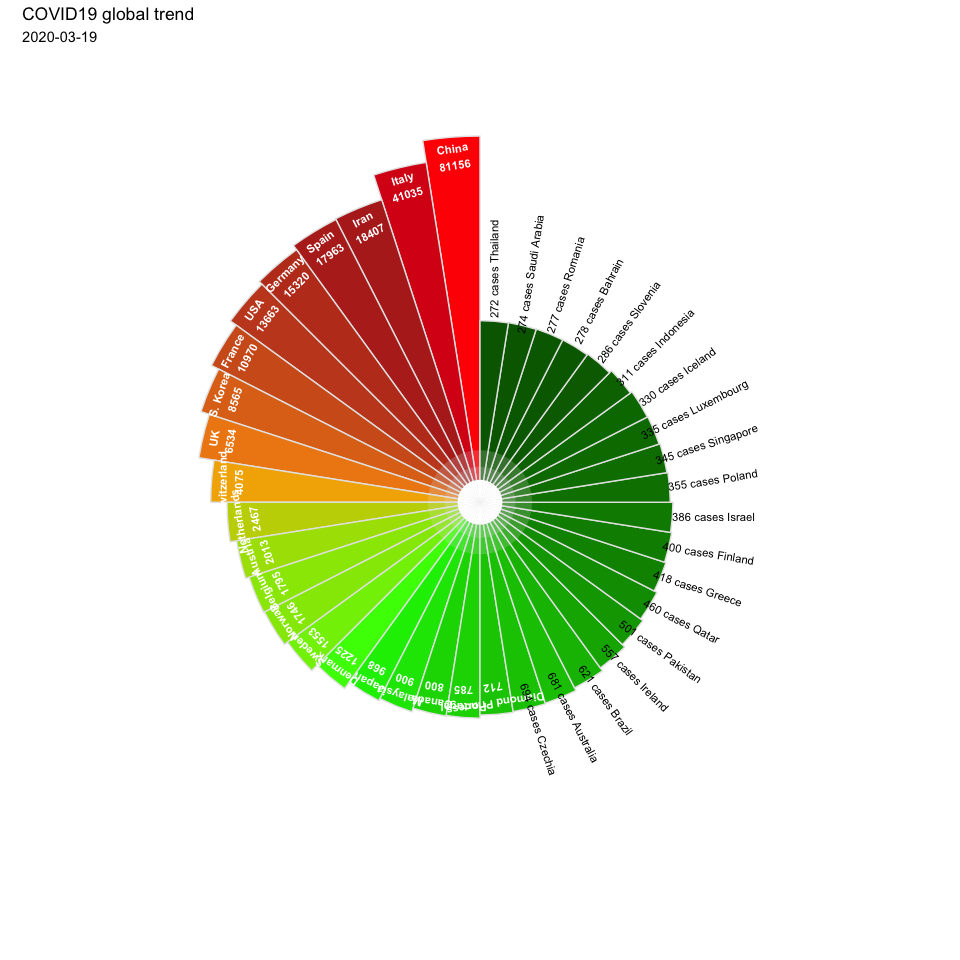

```r
require(dplyr)

y <- res$historical
d <- y["global"]

time = as.Date("2020-03-19")
dd <- filter(d, date == time) %>%
    arrange(desc(cases))

dd = dd[1:40, ]
dd$country = factor(dd$country, levels=dd$country)

dd$angle = 1:40 * 360/40
require(ggplot2)
p <- ggplot(dd, aes(country, cases, fill=cases)) +
    geom_col(width=1, color='grey90') +
    geom_col(aes(y=I(5)), width=1, fill='grey90', alpha = .2) +
    geom_col(aes(y=I(3)), width=1, fill='grey90', alpha = .2) +
    geom_col(aes(y=I(2)), width=1, fill = "white") +
    scale_y_log10() +
    scale_fill_gradientn(colors=c("darkgreen", "green", "orange", "firebrick","red"), trans="log") +
    geom_text(aes(label=paste(country, cases, sep="\n"),
                  y = cases *.8, angle=angle),
            data=function(d) d[d$cases > 700,],
            size=3, color = "white", fontface="bold", vjust=1)  +
     geom_text(aes(label=paste0(cases, " cases ", country),
                  y = max(cases) * 2, angle=angle+90),
            data=function(d) d[d$cases < 700,],
            size=3, vjust=0) +
    coord_polar(direction=-1) +
    theme_void() +
    theme(legend.position="none") +
    ggtitle("COVID19 global trend", time)
p
```

Number of days since 1 million cases per country

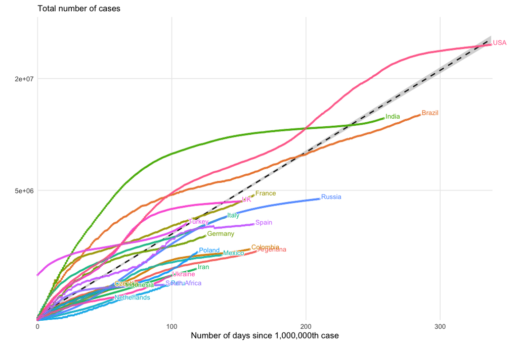

```r
require(dplyr)
require(ggplot2)
require(shadowtext)
y <- res$historical
d <- y["global"]



dd <- d %>%
  as_tibble %>%
  filter(cases > 1000000) %>%
  group_by(country) %>%
  mutate(days_since_1m = as.numeric(date - min(date))) %>%
  ungroup




breaks=c(1000, 10000, 20000, 50000, 500000,500000,5000000,20000000)


p <- ggplot(dd, aes(days_since_1m, cases, color = country)) +
  geom_smooth(method='lm', aes(group=1),
              data = dd,
              color='grey10', linetype='dashed') +
  geom_line(size = 0.8) +
  geom_point(pch = 21, size = 1) +
  scale_y_log10(expand = expansion(add = c(0,0.1)),
                breaks = breaks, labels = breaks) +
  scale_x_continuous(expand = expansion(add = c(0,1))) +
  theme_minimal(base_size = 14) +
  theme(
    panel.grid.minor = element_blank(),
    legend.position = "none",
    plot.margin = margin(3,15,3,3,"mm")
  ) +
  coord_cartesian(clip = "off") +
  geom_shadowtext(aes(label = paste0(" ",country)), hjust=0, vjust = 0,
                  data = . %>% group_by(country) %>% top_n(1,days_since_1m),
                  bg.color = "white") +
  labs(x = "Number of days since 1,000,000th case", y = "",
       subtitle = "Total number of cases")
print(p)
```

## Dashboard

dashboard could launch as below:

```r
dashboard()
```

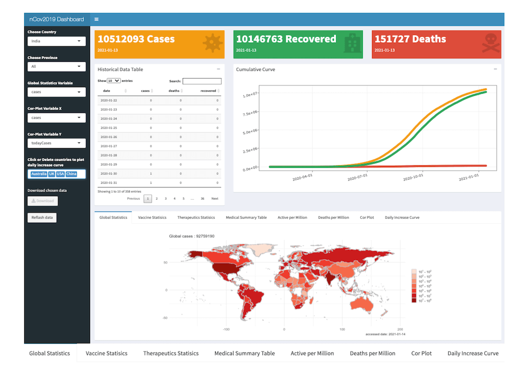

## statistic item explanation

| statistic | explain |
| --- | --- |
| active | active number = comfirmed cases - deaths - recoveredd |
| activePerOneMillion | active number / million population |
| cases | comfirmed cases |
| casesPerOneMillion | comfirmed cases / million population |
| continent | continent |
| country | country |
| critical | Critical patients |
| criticalPerOneMillion | Critical patients / million population |
| date | date |
| deaths | deaths |
| deathsPerOneMillion | deaths patients / million population |
| oneCasePerPeople | oneCasePerPeople |
| oneDeathPerPeople | oneDeathPerPeople |
| oneTestPerPeople | oneTestPerPeople |
| population | population |
| recovered | recovered |
| recoveredPerOneMillion | recoveredPerOneMillion |
| tests | COVID-19 test |
| testsPerOneMillion | COVID-19 test / million population |
| todayCases | comfirm cases in today |
| todayDeaths | comfirm cases in today |
| todayRecovered | comfirm cases in today |
| updated | the latest update time |